# TELG1011 - Reporte de Mini-proyecto #1

**Miembros del Grupo:**

José Santiago Sacón Yanchaguano, 201804572

Oliver Antonio Trujillo Mora, 201709045

**Fecha: 11/29, 2021**

## PROYECTO: INVESTIGACION ACERCA DE APLICACIONES DE LOS FILTROS ADAPTIVOS

## Introduccion

En la actualidad el procesamiento digital de señales se ha convertido en uno de los campos más importantes dentro de lo relacionado a las nuevas tecnologías, sobretodo las tecnologías de la información. A través de los años se ha buscado la forma de manipular distintos tipos de señales de acuerdo a nuestras necesidades y capacidades, lo que ha devenido en el desarrollo de nuevas tecnologías o el mejoramiento de las preexistentes. Una de las herramientas más útiles para procesar señales son los filtros. Existen varios tipos de filtros, diseñados para eliminar ruido o para permitir el paso de ciertas frecuencias y que, de acuerdo a la configuración o su tipo, alteran el comportamiento de las señales o la salida de un sistema. Estos filtros serán implementados de acuerdo a las necesidades de los usuarios y al tipo de señal con el que estamos trabajando. El presente proyecto tiene como tema central el uso de filtros FIR en la eliminación de ruido de una señal de entrada.

## Investigación

### Filtro

Un filtro es un sistema electrónico utilizado para filtrar señales de disntintas maneras, su funciinalidad consiste en dejar pasar ciertas señales eléctricas a una determinada frecuencia o rangos de frecuencias. Este dispositivo deja pasar, suprime o separa un conjunto de señales de una mezcla de señales. Son muy utilizados en el área de las telecomunicaciones, como en la televisión y radio. Los filtros se clasifican en 2 tipos, los analógicos y digitales.

Los filtros analógicos son filtros utilizados como su nombre los indica para procesos analógicos o para trabajar con señales de tiempo continuo. Estos filtros se dividen en filtros activos y pasivos dependiendo de la utilidad y tipos de elementos que se empleen para su solución.

#### Filtro activo

Un filtro activo es un filtro electrónico diferenciado por el uso de uno o más componentes activos.

#### Filtro pasivo

Un filtro pasivo es un filtro electrónico diferenciado por el uso de uno o más componentes pasivos

Hay distintos tipos de filtros analógicos dependiendo de la aplicación que se desee realizar. En términos prácticos, estos se dividen en 4 tipos:

#### Filtro pasa bajo:

Este filtro solo deja pasar señales bajo una determinada frecuencia de corte y bloquea las frecuencias por encima de ella.

#### Filtro pasa alto:

Este filtro solo deja pasar señales mayor a una determinada frecuencia de corte y bloquea las frecuencias por debajo de ella.

#### Filtro pasa banda:

Este filtro permite el paso de un rango de frecuencias ubicado entre una frecuencia de corte menor y una frecuencia de corte mayor y rechaza las frecuencias fuera de este rango.

#### Filtro rechaza banda:

Este filtro es lo contrario al filtro pasa banda, debido a que, atenúa las frecuencias ubicadas entre una frecuencia de corte menor y una mayor, permitiendo el paso de las frecuencias fuera de este rango.

Los filtros digitales son sistemas electrónicos que operan sobre señales discretas y cuantizadas, diseñando e implementado con tecnología digital. Es un proceso matemático digitalizado que toma una señal de entrada en forma de secuencia de números y la modifica produciendo una señal de salida que también es una secuencia de números pero con ciertas características atenuadas o corregidas en base a funcionalidades requeridas. [1]

En la actualidad del uso de filtros digitales posee ciertas ventajas sobre los analógicos, como: Al ser sowtware programable, son sencillos de testear y montar. Son más fáciles de implementar porque requieren operaciones aritméticas básicas como la suma/resta y multiplicación. No poseen derivas por humedad o temperatura, ni necesitan componentes de precisión. No tienen problemas por variación de fabricación o de edad. [2]

Entre otras variaciones o derivados de los filtros está el filtro adaptivo, en el cual, sus coeficientes se actualizan por medio de un algoritmo que funciona con un criterio predefinido, en el cual, puede minimizarse el error cuadrático medio como en el caso MLS. La velocidad de este proceso puede verse afectada dependiendo de la implementación y tipo de señales que se manipulen. En el filtro adaptivo hay un factor muy importante a tomar en cuenta, se le denomina "error de estimación", el cual se denomina como la resta entre la respuesta deseada y la salida del filtro adaptivo, el cual, se utiliza para controlar los valores de un conjunto de parámetros ajustables para el desarrollo del filtro. [3]

Por otra parte, está el filtro Wiener, fabricado en la década de 1940, es un filtro utilizado para el procesamiento digital de señales, su propósito supera la de un filtro normal, su funcionamiento lo incia desde un enfoque estadístico. Se asume información de las características espectrales de la señal y se encuentra el filtro LTI, cuya salida será la más parecida posible a la señal original. Este filtro es muy usado en el proceso de deconvolución. [4]

#### Optimización

Un problema de optimización es un proceso que su propósito se basa en maximizar o minimizar el valor de una variable. En otras palabras, su función es calcular el valor máximo o mínimo de una función. Por ejemplo: disminuir el error en una medición, minimizar la cantidad de material para construir un prototipo, etc.

¿Cómo se plantea?

1)Inicialmente se identifica las variables que da el enunciado

2)Plantear una relación entre las variables X e Y

3)Se despeja una de ellas en función de la otra

4)Buscar la expresión analítica que debemos optimizar referentes a las expresiones del problema planteado.

5)Derivamos e igualamos a 0 para encontrar los extremos.

6)Se deriva por segunda vez la función para comprobar el resultado y averiguar si se obtuvo un máximo o un mínimo.

Tiene una cierta relación con la estimación de error, ya que, este se utiliza para tratar de disminuir el error en las diversas aplicaciones donde se utiliza. [5]

#### Algoritmo de Máxima pendiente(Steepste-Descent)

Este método ejecuta una búsqueda de la solución de Wiener circulando por la superficie de error en dirección al sentido negativo del gradiente, siguiendo los siguientes pasos:

1)Inicialmente el algoritmo posee un valor inicial de los pesos del filtro definido por Wo, dicho parámetro sirve para dar una ubicación del punto óptimo para trabajar. De manera ideal, sería una estimación de la solución de Wiener, pero si no se tiene cierta información previa, se comienza el proceso con el vector nulo.

2)Se hace una evaluación sobre el gradiente en la estimación actual.

3)Se actualiza los valores de la estimación actualizado mediante la adición de un factor de corrección en dirección al sentido opuesto al del vector gradiente.

4)Se realiza nuevamente el paso 2 y se repite el proceso.

Estas correcciones sucesivas que se aplican a los coeficientes del filtro cada que se ejecuta el algoritmo van en la dirección negativa del gradiente y dirigen al punto de error mínimo cuadrático medio, de esta manera se va optimizando el proceso en cada iteración, por lo que, el vector de pesos logra adquirir su valor óptimo Wopt. [3]

#### Aplicación del filtro adaptivo

La habilidad y capacidad de un filtro adaptativo de operar de excelente manera en ambientes desconocidos rastreando variaciones estadísticas en el tiempo de una entrada, convierte a los filtros adaptativos en poderosos dispositivos para aplicaciones de procesamiento de señales y de control, tales como en radares, comunicaciones, sismología, entre otras.

Una de las aplicaciones muy utilizadas de los filtros adaptivos se da en el área de las telecomunicaciones, en específico en la transmisión de señales, es para la, eliminación o cancelación de ruido:

En distintas clases de aplicaciones, el filtro adaptativo sirve para eliminar la interferencia desconocida que se encuentra contenida en la señal básica en determinado sentido. La señal básica resultante es utilizada como la respuesta deseada para el filtro adaptativo, la señal de referencia se selecciona como entrada del filtro. La señal de referencia se empieza a suministrar a partir de un sensor designado o un conjunto de sensores. La señal de entrada de este filtro adaptable es tipo una fuente de ruido, y la respuesta de la señal deseada es una fuente que contiene ruido en ella. Luego de varias iteraciones, la diferencia entre la señal de salida, la señal esperada y el filtro adaptativo es una estimación muy aproximada de la fuente de la señal.

Otra aplicación del filtro adaptivo utilizada es la predicción de señales:

En algunas aplicaciones, el efecto del filtro adaptativo se utiliza como la mejor predicción para el actual valor de la señal aleatoria, y así proporcionar un sentido. Por tanto, el valor actual de la señal es utilizada como la respuesta deseada del filtro adaptativo. El valor pasado de la señal se aplica a la entrada del filtro. Dependiendo del tipo de aplicación que se encuentre realizando, el error en la señal de salida o estimación del filtro adaptativo puede ser utilizado como una salida del sistema. En el primer caso, el sistema es utilizado como predictor; En este último caso, el sistema es utilizado como filtro de error predicho. Esta característica del filtro adaptivo tiene diversas aplicaciones y funcionalidades dependiendo de los requerimientos y habilidades del fabricante. [6]

# Código

### TAREA 1: Generación de secuencias / señales

```
Ingrese la longitud de la secuencia M (debe ser mayor a 255):  500
Varianza: 0.5 SNR [0]
      Señal con ruido         Señal de ruido
```

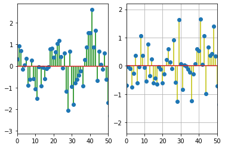

```
Varianza: 0.05 SNR [10]
      Señal con ruido         Señal de ruido
```

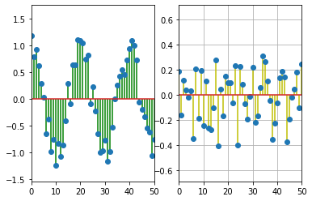

```
Varianza: 0.005 SNR [20]
      Señal con ruido         Señal de ruido
```

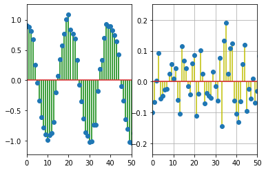

```
Varianza: 0.0005 SNR [30]
      Señal con ruido         Señal de ruido
```

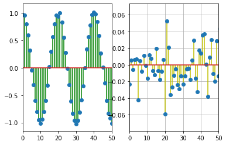

```python
import numpy as np
import matplotlib.pyplot as p
import math as m

valido=False
while not valido:
        N=int(input("Ingrese la longitud de la secuencia M (debe ser mayor a 255):  "))
        valido=N>=255
        if not valido:
            print('Lo siento, el valor no es mayor a 255, vuelva a intentarlo')

w0=(np.pi/10)
n=np.arange(0,N+1,1)
A=1
x1=A*np.cos(w0*n)
var_w1=np.array([1/2,1/20,1/200,1/2000])
SNRdB=np.array([0,10,20,30])
for i in var_w1:
    w = np.sqrt(i)*np.random.randn(N+1)
    x=x1+w
    print("Varianza:",i,"SNR",SNRdB[np.where(var_w1==i)])
    print("     ","Señal con ruido","       ","Señal de ruido")
    p.subplot(1,2,1)
    p.stem(np.linspace(0,N,len(x)),x,'g')
    p.xlim(0,50)
    p.subplot(1,2,2)
    p.xlim(0,50)
    p.stem(np.linspace(0,N,len(w)),w,'y')
    p.grid();
    p.show()
```

### TAREA 2: Implementación de un filtro y resultados de filtrado

[output not shown]

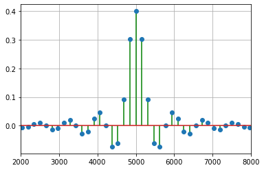

```python
import scipy.signal as signal
numtaps = 65
fs = 10000
fc = 0.2 * fs
cutoff = 2 * fc / fs
b = signal.firwin(numtaps, cutoff)
print("     ","Respuesta de frecuencia del filtro FIR")
p.stem(np.linspace(0,fs,len(b)),b,'g',use_line_collection=True)
p.xlim(2000,8000)
p.grid();
```

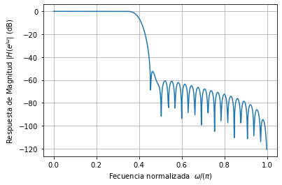

```python
f1 = np.arange(0,0.5,0.001)
w2, H = signal.freqz(b, 1, 2*np.pi*f1)
p.plot(w2 / np.pi, 20 * np.log10(np.abs(H)))
p.grid();
p.xlabel(r'Fecuencia normalizada  $\omega/ (\pi)$')
p.ylabel(r'Respuesta de Magnitud $|H(e^{j\omega}|$ (dB)');
```

```
Varianza: 0.5 SNR [0]
      Señal con ruido         Señal filtrada
```

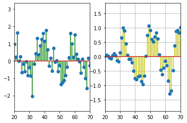

```
Varianza: 0.05 SNR [10]
      Señal con ruido         Señal filtrada
```

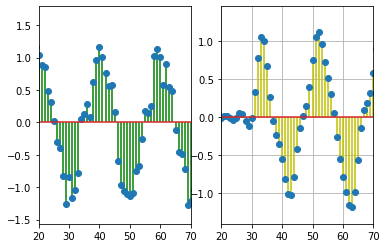

```
Varianza: 0.005 SNR [20]
      Señal con ruido         Señal filtrada
```

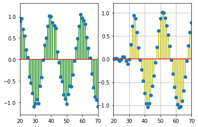

```
Varianza: 0.0005 SNR [30]
      Señal con ruido         Señal filtrada
```

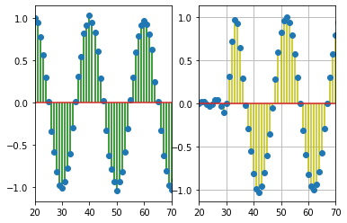

```python
for i in var_w1:
    w = np.sqrt(i)*np.random.randn(N+1)
    x=x1+w
    y = signal.lfilter(b, 1, x)
    print("Varianza:",i,"SNR",SNRdB[np.where(var_w1==i)])
    print("     ","Señal con ruido","       ","Señal filtrada")
    p.subplot(1,2,1)
    p.stem(np.linspace(0,N,len(x)),x,'g')
    p.xlim(20,70)
    p.subplot(1,2,2)
    p.stem(np.linspace(0,N,len(y)),y,'y')
    p.xlim(20,70)
    p.grid();
    p.show()
```

## Conclusiones

-La varianza de la señal afecta directamente a la misma cuando se combina con una señal de ruido. Cuando la varianza tiene un valor muy grande la distorción de la señal es absoluta.

-A medida de que la señal se reduce, se reduce también la distorción que presenta la señal de entrada cuando se la fusiona con la señal de ruido.

-Cuando el filtro FIR trabaja sobre la señal, reduce e ruido mezclado con la señal útil. Este filtrado es un proceso en el cual se extrae la parte esencial de una señal y se la separa de otros componentes extraños provenientes de señaes de ruido externas a la misma.

-Los filtros adaptativos son aquellos cuyos coceficientes pueden ser actualizados de acuerdo a un criterio definido. Esta adaptación y su velocidad puede variar dependiendo de la implementación del filtro y qué tipo de señales es capaz de manejar y procesar.

## Referencias

[1] udlap. [En línea]. Available: http://catarina.udlap.mx/u_dl_a/tales/documentos/lem/torres_d_ld/capitulo1.pdf.

[2] ehu. [En línea]. Available: http://www.ehu.eus/procesadoinsvirtual/T6_ventajas.html.

[3] bookcentral. [En línea]. Available: https://ebookcentral.proquest.com/lib/espol/detail.action?docID=311323.

[4] springer. [En línea]. Available: https://link.springer.com/book/10.1007/978-3-642-33561-7.

[5] yosoytuprofe. [En línea]. Available: https://yosoytuprofe.20minutos.es/2018/05/13/problemas-de-optimizacion-de-funciones/.

[6] programmer. [En línea]. Available: https://programmerclick.com/article/61662219652/.